# Part One Explore

```r
library(tidyverse)
install.packages(c("nycflights13", "gapminder", "Lahman"))
library(nycflights13)
library(gapminder)
library(Lahman)
```

#### Hypothesis confirmation

It’s possible to divide data analysis into two camps: hypothesis generation and hypothesis confirmation (sometimes called confirmatory analysis). The focus of this book is unabashedly on hypothesis generation, or data exploration. Here you’ll look deeply at the data and, in combination with your subject knowledge, generate many interesting hypotheses to help explain why the data behaves the way it does. You evaluate the hypotheses informally, using your scepticism to challenge the data in multiple ways.

The complement of hypothesis generation is hypothesis confirmation. Hypothesis confirmation is hard for two reasons:

You need a precise mathematical model in order to generate falsifiable predictions. This often requires considerable statistical sophistication.

You can only use an observation once to confirm a hypothesis. As soon as you use it more than once you’re back to doing exploratory analysis. This means to do hypothesis confirmation you need to “preregister” (write out in advance) your analysis plan, and not deviate from it even when you have seen the data. We’ll talk a little about some strategies you can use to make this easier in modelling.

It’s common to think about modelling as a tool for hypothesis confirmation, and visualisation as a tool for hypothesis generation. But that’s a false dichotomy: models are often used for exploration, and with a little care you can use visualisation for confirmation. The key difference is how often do you look at each observation: if you look only once, it’s confirmation; if you look more than once, it’s exploration. ####

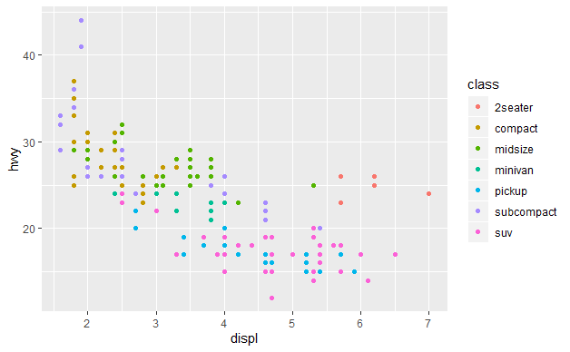

```r
library(ggplot2)
ggplot(mpg, aes(x = displ, y = hwy)) + geom_point(aes(colour = class))
```

```r
dput(mtcars)
```

[output not shown]

```r
ggplot(data = mpg, aes(x = displ, y = hwy)) + geom_point()
```

```r
ggplot(data = mpg) + geom_point(mapping = aes(x = displ, y = hwy))
```

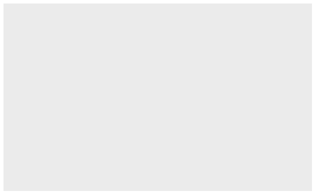

```r
ggplot(data = mpg)
```

3.2.4 Exercises Run ggplot(data = mpg). What do you see?

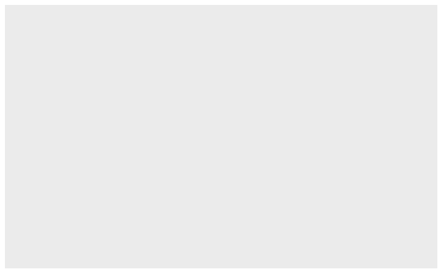

```r
ggplot(data = mpg)
```

2.How many rows are in mpg? How many columns?

```r
dim(mpg)
```

```
[1] 234  11
```

3.What does the drv variable describe? Read the help for ?mpg to find out.

```r
?mpg
```

f = front-wheel drive, r = rear wheel drive, 4 = 4wd

4.Make a scatterplot of hwy vs cyl.

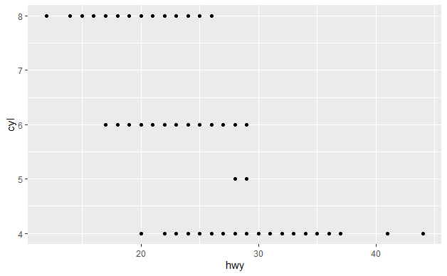

```r
ggplot(data = mpg, aes(x = hwy, y = cyl)) + geom_point()
```

4 . What happens if you make a scatterplot of class vs drv? Why is the plot not useful?

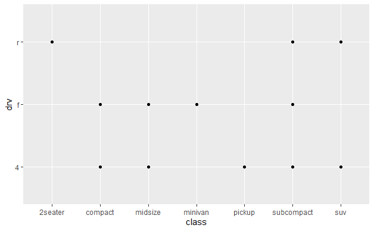

```r
ggplot(data = mpg, aes(x = class, y = drv)) + geom_point()
```

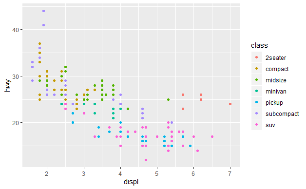

```r
ggplot(data = mpg, aes(x = displ, y = hwy, colour = class)) + geom_point()
```

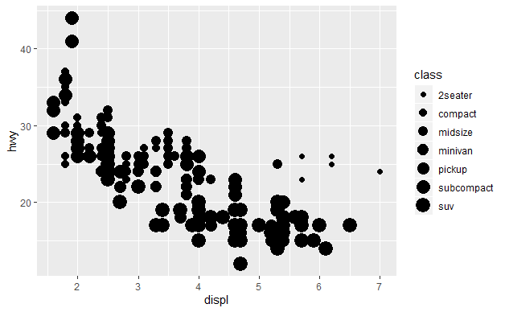

```r
ggplot(data = mpg, aes(x = displ, y = hwy, size = class)) + geom_point()
```

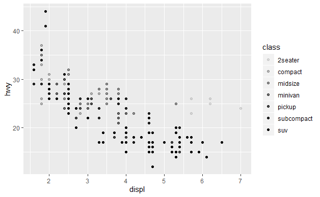

```r
ggplot(data = mpg, aes(x = displ, y = hwy, alpha = class)) + geom_point()
```

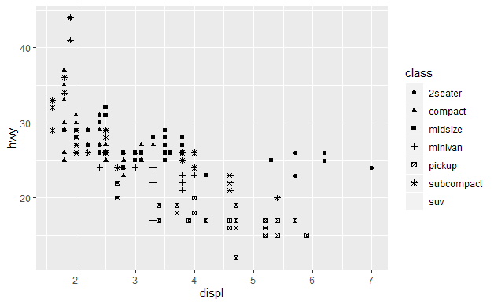

```r
ggplot(data = mpg, aes(x = displ, y = hwy, shape = class)) + geom_point()
```

```r
ggplot(data = mpg, aes(x = displ, y = hwy, color = "blue")) + geom_point()
```

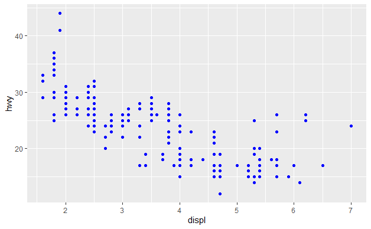

```r
ggplot(data = mpg) + geom_point(mapping = aes(x = displ, y = hwy), color = "blue")
```

```r
ggplot(data = mpg, aes(x = displ, y = hwy, color = "blue")) + geom_point()
```

```r
ggplot(data = mpg, aes(x = displ, y = hwy), color = "blue") + geom_point()
```

1. What’s gone wrong with this code? Why are the points not blue?

```r
ggplot(data = mpg, aes(x = displ, y = hwy, color = "blue")) + geom_point()
```

2. Which variables in mpg are categorical? Which variables are continuous? (Hint: type ?mpg to read the documentation for the dataset). How can you see this information when you run mpg?

```r
View(mpg)
```

3. Map a continuous variable to color, size, and shape. How do these aesthetics behave differently for categorical vs. continuous variables?

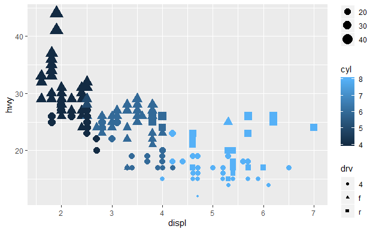

```r
ggplot(data = mpg) + geom_point(mapping = aes(x = displ, y = hwy, color = cyl, size = hwy, shape = drv))
```

4.What happens if you map the same variable to multiple aesthetics?

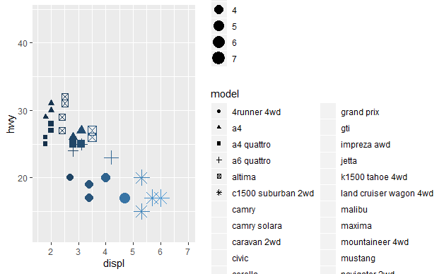

```r
ggplot(data = mpg) + geom_point(mapping = aes(x = displ, y = hwy, color = displ, size = displ, shape = model))
```

5. What does the stroke aesthetic do? What shapes does it work with?

Stroke controls the width of the border, for shapes that have one.

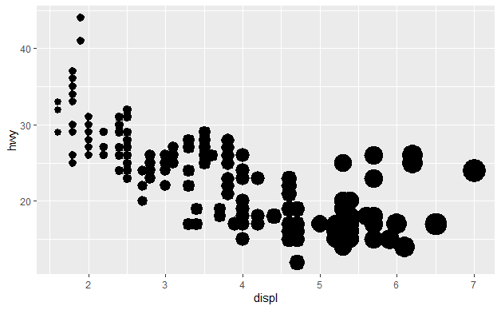

```r
ggplot(data = mpg, aes(x = displ, y = hwy, stroke = displ), shape = 21) + geom_point()
```

6. What happens if you map an aesthetic to something other than a variable name, like aes(colour = displ < 5)? Note, you’ll also need to specify x and y.

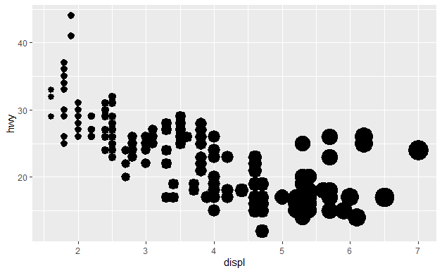

```r
ggplot(data = mpg, aes(x = displ, y = hwy, stroke = displ), color = displ < 5, shape = 21) + geom_point()
```

```r
str(mpg)
```

```
Classes ‘tbl_df’, ‘tbl’ and 'data.frame':   234 obs. of  11 variables:
 $ manufacturer: chr  "audi" "audi" "audi" "audi" ...
 $ model       : chr  "a4" "a4" "a4" "a4" ...
 $ displ       : num  1.8 1.8 2 2 2.8 2.8 3.1 1.8 1.8 2 ...
 $ year        : int  1999 1999 2008 2008 1999 1999 2008 1999 1999 2008 ...
 $ cyl         : int  4 4 4 4 6 6 6 4 4 4 ...
 $ trans       : chr  "auto(l5)" "manual(m5)" "manual(m6)" "auto(av)" ...
 $ drv         : chr  "f" "f" "f" "f" ...
 $ cty         : int  18 21 20 21 16 18 18 18 16 20 ...
 $ hwy         : int  29 29 31 30 26 26 27 26 25 28 ...
 $ fl          : chr  "p" "p" "p" "p" ...
 $ class       : chr  "compact" "compact" "compact" "compact" ...
```

```r
ggplot(data = mpg) + geom_point(mapping = aes(x = displ, y = hwy))
```

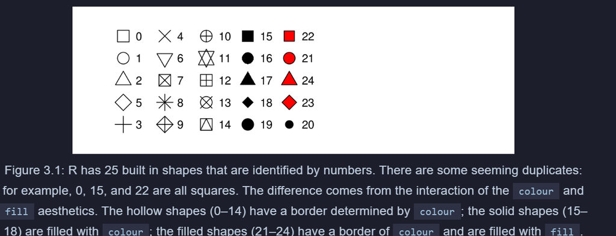

** FACETS - takes discrete and categorical variable**

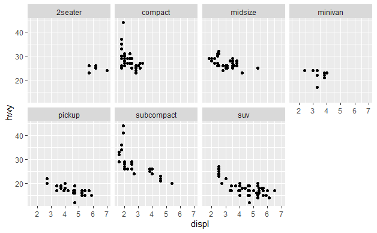

```r
ggplot(data = mpg) +
  geom_point(mapping = aes(x = displ, y = hwy)) +
  facet_wrap(~ class, nrow = 2)
```

```r
?mpg
```

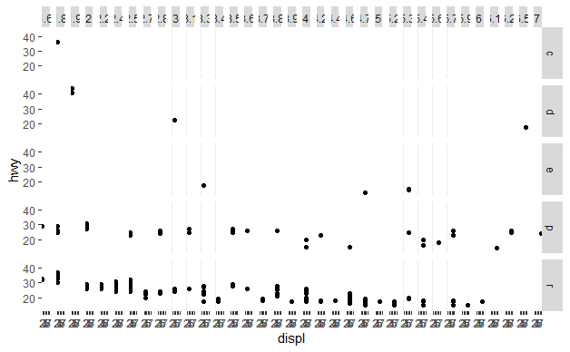

```r
ggplot(data = mpg) +
  geom_point(mapping = aes(x = displ, y = hwy)) +
  facet_grid(fl~ displ)
```

To facet your plot on the combination of two variables, add facet_grid() to your plot call. The first argument of facet_grid() is also a formula. This time the formula should contain two variable names separated by a ~.

#### If you prefer to not facet in the rows or columns dimension, use a . instead of a variable name, e.g. + facet_grid(. ~ cyl).

1. What happens if you facet on a continuous variable? There is one facet for each value e.g. a facet on displ.

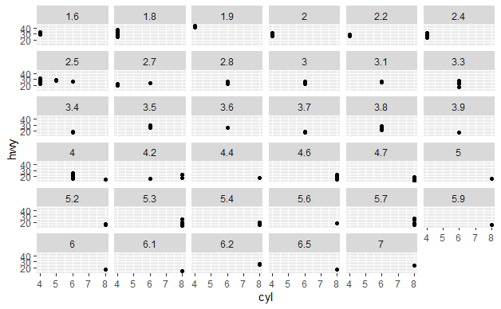

```r
ggplot(data = mpg) +
  geom_point(mapping = aes(x = cyl, y = hwy)) +
  facet_wrap(~ displ)
```

2. What do the empty cells in plot with facet_grid(drv ~ cyl) mean? How do they relate to this plot?

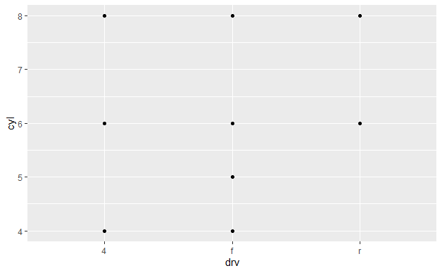

```r
ggplot(data = mpg) +
  geom_point(mapping = aes(x = drv, y = cyl))
```

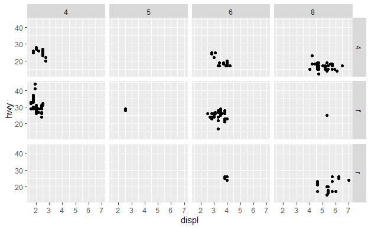

```r
ggplot(data = mpg) +
  geom_point(mapping = aes(x = displ, y = hwy)) +
  facet_grid(drv ~ cyl)
```

the blank boxes tell us that there is no data, satisfying the conditions on the right and top bars.

3. What plots does the following code make? What does . do?

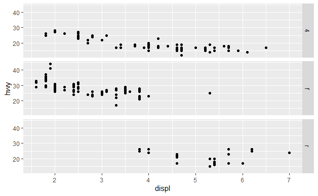

```r
ggplot(data = mpg) + geom_point(mapping = aes(x = displ, y = hwy)) + facet_grid(drv ~ .)
```

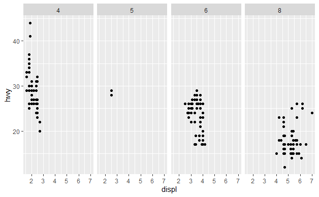

```r
ggplot(data = mpg) + geom_point(mapping = aes(x = displ, y = hwy)) + facet_grid(. ~cyl)
```

the placement of “.” differs the presentation of data, either row wise or coloumn wise. “.” on the left side plots the data coloumn wise with the parameter marked on the top

4. Take the first faceted plot in this section:

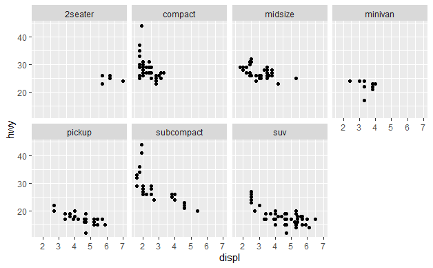

```r
ggplot(data = mpg) + geom_point(mapping = aes(x = displ, y = hwy)) + facet_wrap(~class, nrow = 2)
```

4 . What are the advantages to using faceting instead of the colour aesthetic? What are the disadvantages? How might the balance change if you had a larger dataset?

With faceting it is easier to examine the indivual classes. With coloring it is easier to see how the classes are clustered overall. With larger datasets it’s more likely that you want to see the overall clustering instead of the individual point clouds.

5. Read ?facet_wrap. What does nrow do? What does ncol do? What other options control the layout of the individual panels? Why doesn’t facet_grid() have nrow and ncol arguments?

Facet grids do not have these configuration because the rows and cols are determined by the specified attributes.

6.When using facet_grid() you should usually put the variable with more unique levels in the columns. Why?